# Double Logistic Selectivity (3-parameter formulation)

## 1 Overview

This notebook documents the 3-parameter double logistic selectivity curve used for prior elicitation in the EBS pollock assessment workflow. The formulation allows dome-shaped selectivity, where vulnerability increases with age to a peak and then declines. This behavior is motivated by gear avoidance at older ages, ontogenetic habitat shifts, or differential availability between age classes.

Within integrated assessments, double-logistic forms are often a practical extension of monotone logistic selectivity because they can represent declining vulnerability at older ages while remaining low-dimensional (Punt, Hurtado-Ferro, and Whitten 2013). Interpretation still requires care: dome shape can be confounded with natural mortality and cohort processes if independent information is weak (Thompson 1994).

## 2 Model definition

Let age be $a$, with parameters $p_1$, $p_2$, and $p_3$ and derived inflection points $\gamma_1$ and $\gamma_2$:

$$\gamma_1 = p_1 + p_2, \qquad
\gamma_2 = 2p_1 + p_2 + p_3.$$

The ascending limb is a standard logistic and the descending limb is one minus a logistic:

$$\text{asc}(a) = \frac{1}{1 + \exp\left[-\log(19)\,\frac{a - \gamma_1}{p_1}\right]},$$

$$\text{desc}(a) = 1 - \frac{1}{1 + \exp\left[-\log(19)\,\frac{a - \gamma_2}{p_3}\right]}.$$

The full double logistic selectivity is

$$\text{sel}(a) = \min\left(1,\ \frac{\text{asc}(a)\,\text{desc}(a)}{0.95^2}\right).$$

### 2.1 Interpretation

- $p_1 > 0$ controls the ascending slope and is the distance from $\gamma_1$ (50% selectivity) to the 95% point.
- $p_2$ shifts the ascending limb through $\gamma_1 = p_1 + p_2$.
- $p_3 > 0$ controls the descending slope and is the distance from $\gamma_2$ (50% on the descending limb) to the 5% point.
- The dome width is $\gamma_2 - \gamma_1 = p_1 + p_3$.
- The factor $0.95^{-2}$ normalizes the curve so that when both limbs are at 0.95 the product is near 1 (then capped at 1.0).

## 3 Scenarios

**Show R code**

```r
library(ggplot2)
library(dplyr)
library(tidyr)
library(patchwork)

dbl_logistic_sel <- function(age, p1, p2, p3) {
  gamma1 <- p1 + p2
  gamma2 <- 2 * p1 + p2 + p3

  asc <- 1 / (1 + exp(-log(19) * (age - gamma1) / p1))
  desc <- 1 - 1 / (1 + exp(-log(19) * (age - gamma2) / p3))

  sel <- asc * desc * 0.95^(-2)
  pmin(sel, 1.0)
}

ages <- seq(1, 15, by = 0.1)

scenarios <- tibble(
  scenario = c(
    "Wide dome",
    "Asymmetric\n(fast rise, slow decline)",
    "Asymmetric\n(slow rise, fast decline)",
    "Nearly asymptotic"
  ),
  p1 = c(2.0, 0.8, 2.0, 1.5),
  p2 = c(4.0, 4.0, 3.0, 4.0),
  p3 = c(2.5, 3.0, 0.8, 8.0)
) %>%
  mutate(
    gamma1 = p1 + p2,
    gamma2 = 2 * p1 + p2 + p3,
    dome_width = gamma2 - gamma1
  )

sel_data <- scenarios %>%
  rowwise() %>%
  do({
    scen <- .
    tibble(
      scenario = scen$scenario,
      age = ages,
      selectivity = dbl_logistic_sel(ages, scen$p1, scen$p2, scen$p3),
      p1 = scen$p1,
      p2 = scen$p2,
      p3 = scen$p3,
      gamma1 = scen$gamma1,
      gamma2 = scen$gamma2
    )
  }) %>%
  ungroup() %>%
  mutate(
    label = sprintf("%s\n(p1=%.1f, p2=%.1f, p3=%.1f)", scenario, p1, p2, p3)
  )
```

**Show R code**

```r
knitr::kable(
  scenarios,
  digits = 2
)
```

Table 1: Scenario parameters and derived inflection points

| scenario | p1 | p2 | p3 | gamma1 | gamma2 | dome_width |
| --- | --- | --- | --- | --- | --- | --- |
| Wide dome | 2.0 | 4 | 2.5 | 6.0 | 10.5 | 4.5 |
| Asymmetric |  |  |  |  |  |  |
| (fast rise, slow decline) | 0.8 | 4 | 3.0 | 4.8 | 8.6 | 3.8 |
| Asymmetric |  |  |  |  |  |  |
| (slow rise, fast decline) | 2.0 | 3 | 0.8 | 5.0 | 7.8 | 2.8 |
| Nearly asymptotic | 1.5 | 4 | 8.0 | 5.5 | 15.0 | 9.5 |

The scenario summary in Table lists the four parameter sets and the derived inflection points ($\gamma_1$, $\gamma_2$) used in the selectivity scenarios.

## 4 Faceted scenario curves

Each scenario appears on its own panel in Figure so the ascent, descent, and dome width can be compared against the 50% and 95% reference lines.

**Show R code**

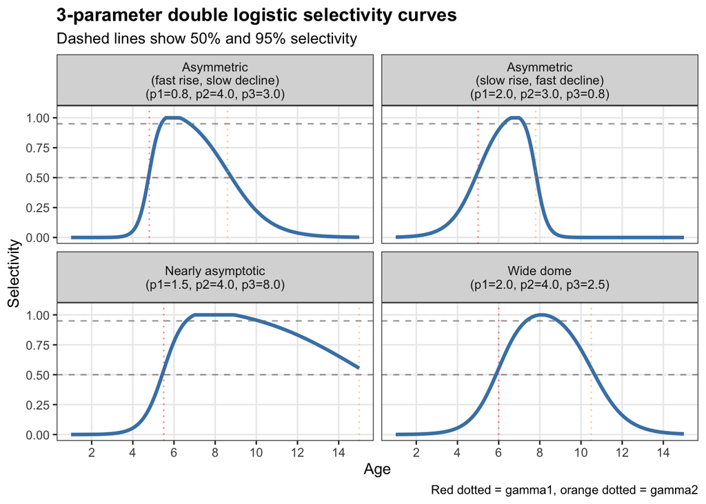

Figure 1: Double logistic selectivity for each parameter scenario.

```r
p1_plot <- ggplot(sel_data, aes(x = age, y = selectivity)) +
  geom_line(linewidth = 1.2, color = "steelblue") +
  geom_hline(yintercept = c(0.5, 0.95), linetype = "dashed",
             color = "gray50", alpha = 0.7) +
  geom_vline(aes(xintercept = gamma1), linetype = "dotted",
             color = "red", alpha = 0.5) +
  geom_vline(aes(xintercept = gamma2), linetype = "dotted",
             color = "orange", alpha = 0.5) +
  facet_wrap(~label, ncol = 2) +
  scale_x_continuous(breaks = seq(2, 14, by = 2)) +
  scale_y_continuous(limits = c(0, 1.05), breaks = seq(0, 1, by = 0.25)) +
  labs(
    title = "3-parameter double logistic selectivity curves",
    subtitle = "Dashed lines show 50% and 95% selectivity",
    x = "Age",
    y = "Selectivity",
    caption = "Red dotted = gamma1, orange dotted = gamma2"
  ) +
  theme_bw(base_size = 11) +
  theme(
    strip.text = element_text(size = 9),
    plot.title = element_text(face = "bold"),
    panel.grid.minor = element_blank()
  )

p1_plot
```

## 5 Overlay comparison

All scenarios are overlaid in Figure to highlight differences in peak age and decline shape when the curves are viewed on a common axis.

**Show R code**

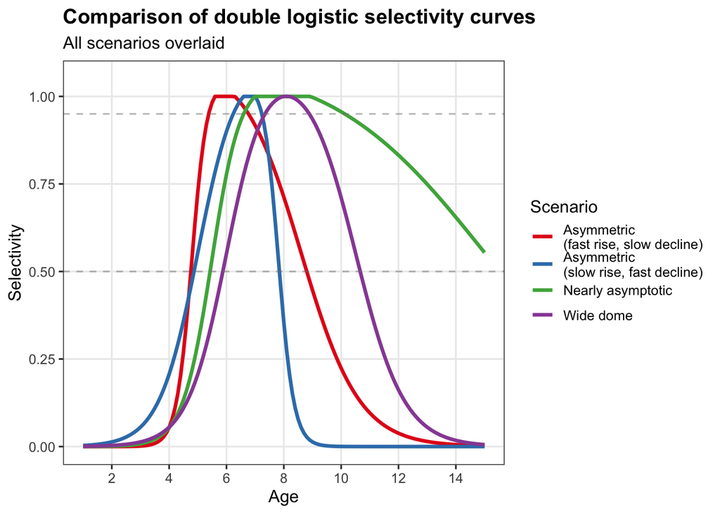

Figure 2: All scenarios overlaid for direct comparison.

```r
p2_plot <- ggplot(sel_data, aes(x = age, y = selectivity, color = scenario)) +
  geom_line(linewidth = 1.2) +
  geom_hline(yintercept = c(0.5, 0.95), linetype = "dashed",
             color = "gray50", alpha = 0.5) +
  scale_x_continuous(breaks = seq(2, 14, by = 2)) +
  scale_y_continuous(limits = c(0, 1.05), breaks = seq(0, 1, by = 0.25)) +
  scale_color_brewer(palette = "Set1", name = "Scenario") +
  labs(
    title = "Comparison of double logistic selectivity curves",
    subtitle = "All scenarios overlaid",
    x = "Age",
    y = "Selectivity"
  ) +
  theme_bw(base_size = 12) +
  theme(
    legend.position = "right",
    plot.title = element_text(face = "bold"),
    panel.grid.minor = element_blank()
  )

p2_plot
```

## 6 Parameter sensitivity analysis

The three panels in Figure show how each parameter changes the curve when the other two are held fixed.

**Show R code**

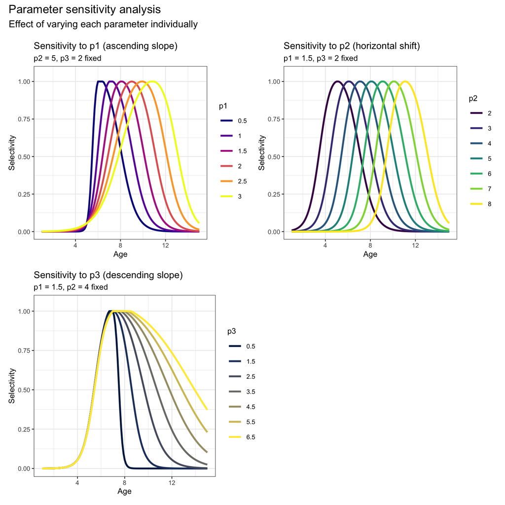

Figure 3: Sensitivity to p1, p2, and p3 with other parameters fixed.

```r
p1_vary <- expand_grid(
  p1 = seq(0.5, 3, by = 0.5),
  p2 = 5,
  p3 = 2,
  age = ages
) %>%
  rowwise() %>%
  mutate(selectivity = dbl_logistic_sel(age, p1, p2, p3)) %>%
  ungroup()

p3a <- ggplot(p1_vary, aes(x = age, y = selectivity, color = factor(p1))) +
  geom_line(linewidth = 1) +
  scale_color_viridis_d(name = "p1", option = "C") +
  scale_y_continuous(limits = c(0, 1.05)) +
  labs(title = "Sensitivity to p1 (ascending slope)",
       subtitle = "p2 = 5, p3 = 2 fixed",
       x = "Age", y = "Selectivity") +
  theme_bw(base_size = 9) +
  theme(legend.position = "right", aspect.ratio = 1)

p2_vary <- expand_grid(
  p1 = 1.5,
  p2 = seq(2, 8, by = 1),
  p3 = 2,
  age = ages
) %>%
  rowwise() %>%
  mutate(selectivity = dbl_logistic_sel(age, p1, p2, p3)) %>%
  ungroup()

p3b <- ggplot(p2_vary, aes(x = age, y = selectivity, color = factor(p2))) +
  geom_line(linewidth = 1) +
  scale_color_viridis_d(name = "p2", option = "D") +
  scale_y_continuous(limits = c(0, 1.05)) +
  labs(title = "Sensitivity to p2 (horizontal shift)",
       subtitle = "p1 = 1.5, p3 = 2 fixed",
       x = "Age", y = "Selectivity") +
  theme_bw(base_size = 9) +
  theme(legend.position = "right", aspect.ratio = 1)

p3_vary <- expand_grid(
  p1 = 1.5,
  p2 = 4,
  p3 = seq(0.5, 6.5, by = 1),
  age = ages
) %>%
  rowwise() %>%
  mutate(selectivity = dbl_logistic_sel(age, p1, p2, p3)) %>%
  ungroup()

p3c <- ggplot(p3_vary, aes(x = age, y = selectivity, color = factor(p3))) +
  geom_line(linewidth = 1) +
  scale_color_viridis_d(name = "p3", option = "E") +
  scale_y_continuous(limits = c(0, 1.05)) +
  labs(title = "Sensitivity to p3 (descending slope)",
       subtitle = "p1 = 1.5, p2 = 4 fixed",
       x = "Age", y = "Selectivity") +
  theme_bw(base_size = 9) +
  theme(legend.position = "right", aspect.ratio = 1)

p_sensitivity <- (p3a | p3b) / (p3c | plot_spacer()) +
  plot_annotation(
    title = "Parameter sensitivity analysis",
    subtitle = "Effect of varying each parameter individually"
  )

p_sensitivity
```

## 7 RTMB implementation with priors

A common approach is to estimate on the log scale for the positive parameters and apply lognormal priors on $p_1$ and $p_3$:

$$\log(p_k) \sim \mathcal{N}(\mu_k, \sigma_k^2), \qquad k \in \{1, 3\}.$$

If using a lognormal prior specified by median $m$ and coefficient of variation $\text{CV}$ on the natural scale, a convenient conversion is

$$\mu = \log(m), \qquad \sigma = \sqrt{\log(\text{CV}^2 + 1)}.$$

Parameter $p_2$ can remain unconstrained (normal prior) or be modeled on the log scale if you want to enforce $p_2 > 0$.

```
outer mgc:  0
```

```
outer mgc:  0
outer mgc:  0.006737636
outer mgc:  0.006737636
outer mgc:  0.001
outer mgc:  0.001
outer mgc:  0.003252194
outer mgc:  0.003252194
outer mgc:  2.5
```

## 8 MCMC evaluation

```
Gradient evaluation took 4.1e-05 seconds
1000 transitions using 10 leapfrog steps per transition would take 0.41 seconds.
Adjust your expectations accordingly!



 Elapsed Time: 0.018 seconds (Warm-up)
               0.196 seconds (Sampling)
               0.214 seconds (Total)



Model 'selectivity_set1' has 3 pars, and was fit using NUTS with a 'diag' metric
1 chain(s) of 1300 total iterations (150 warmup) were used
Average run time per chain was 0.21 seconds
Minimum ESS=360.7 (31.37%), and maximum Rhat=1.015
There were 0 divergences after warmup
```

**Show R code**

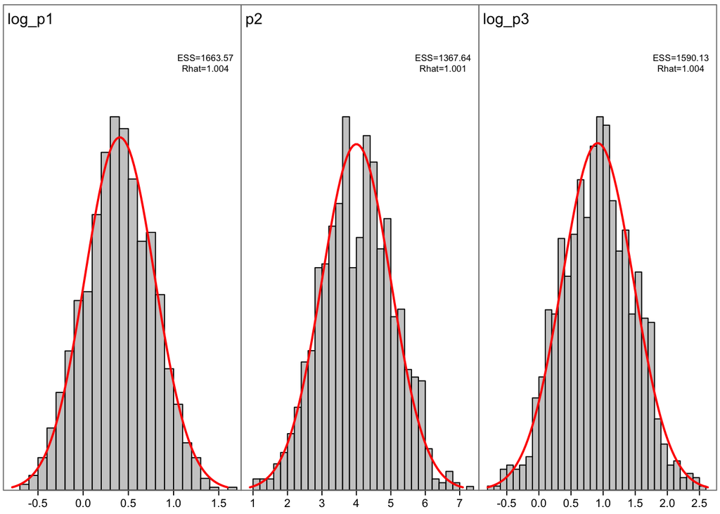

Figure 4: Marginal posterior distributions for selectivity parameters (SparseNUTS, prior set 1).

```r
SparseNUTS::plot_marginals(fit_set1, pars = 1:3)
```

The marginal posterior densities in Figure summarize $(p_1, p_2, p_3)$ under prior set 1.

**Show R code**

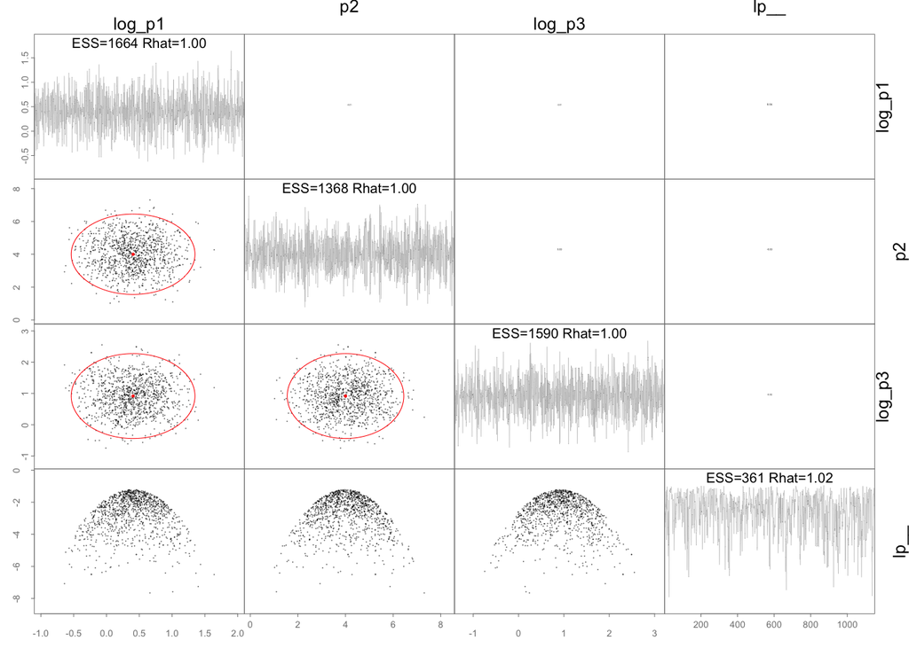

Figure 5: Pairwise posterior scatterplots for selectivity parameters.

```r
pairs(fit_set1)
```

**Show R code**

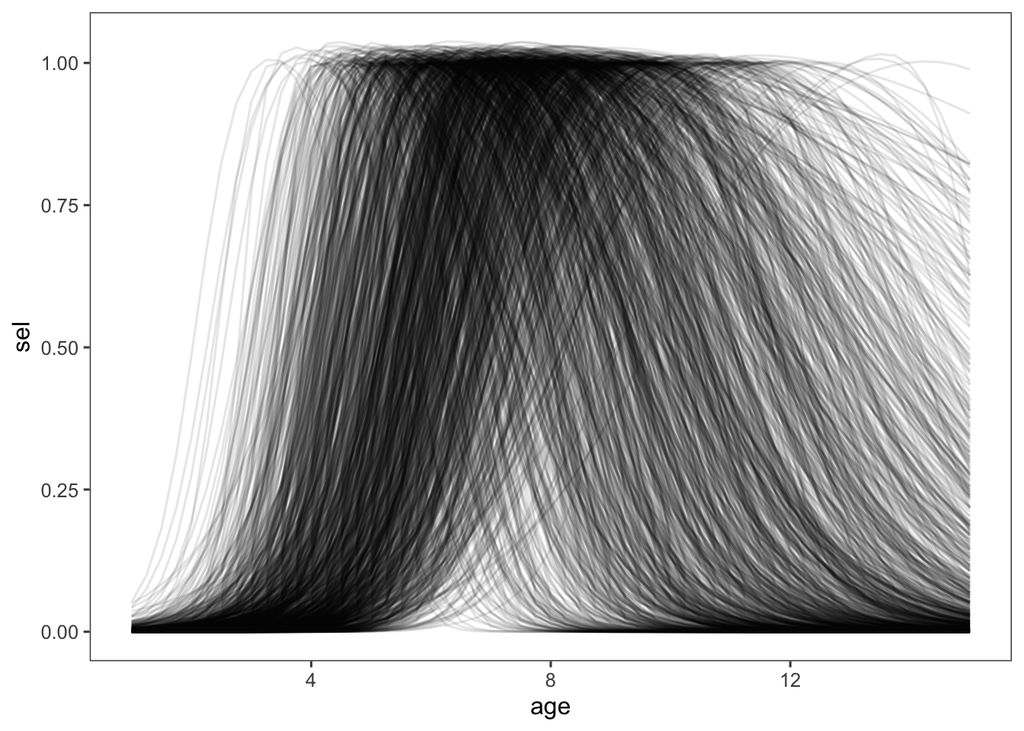

Figure 6: MCMC selectivity draws for prior set 1 (p1 median 1.5, p3 median 2.5, p2 sd 1).

```r
df_set1 <- mcmc_selectivity_df(fit_set1, age)
plot_mcmc_selectivity(df_set1)
```

### 8.1 Additional prior sets

```
Gradient evaluation took 2.6e-05 seconds
1000 transitions using 10 leapfrog steps per transition would take 0.26 seconds.
Adjust your expectations accordingly!



 Elapsed Time: 0.018 seconds (Warm-up)
               0.13 seconds (Sampling)
               0.148 seconds (Total)



Model 'selectivity_set2' has 3 pars, and was fit using NUTS with a 'diag' metric
1 chain(s) of 1300 total iterations (150 warmup) were used
Average run time per chain was 0.15 seconds
Minimum ESS=393.8 (34.24%), and maximum Rhat=1.003
There were 0 divergences after warmup
```

```
Gradient evaluation took 2.2e-05 seconds
1000 transitions using 10 leapfrog steps per transition would take 0.22 seconds.
Adjust your expectations accordingly!



 Elapsed Time: 0.017 seconds (Warm-up)
               0.129 seconds (Sampling)
               0.146 seconds (Total)



Model 'selectivity_set3' has 3 pars, and was fit using NUTS with a 'diag' metric
1 chain(s) of 1300 total iterations (150 warmup) were used
Average run time per chain was 0.15 seconds
Minimum ESS=427 (37.13%), and maximum Rhat=1.005
There were 0 divergences after warmup
```

**Show R code**

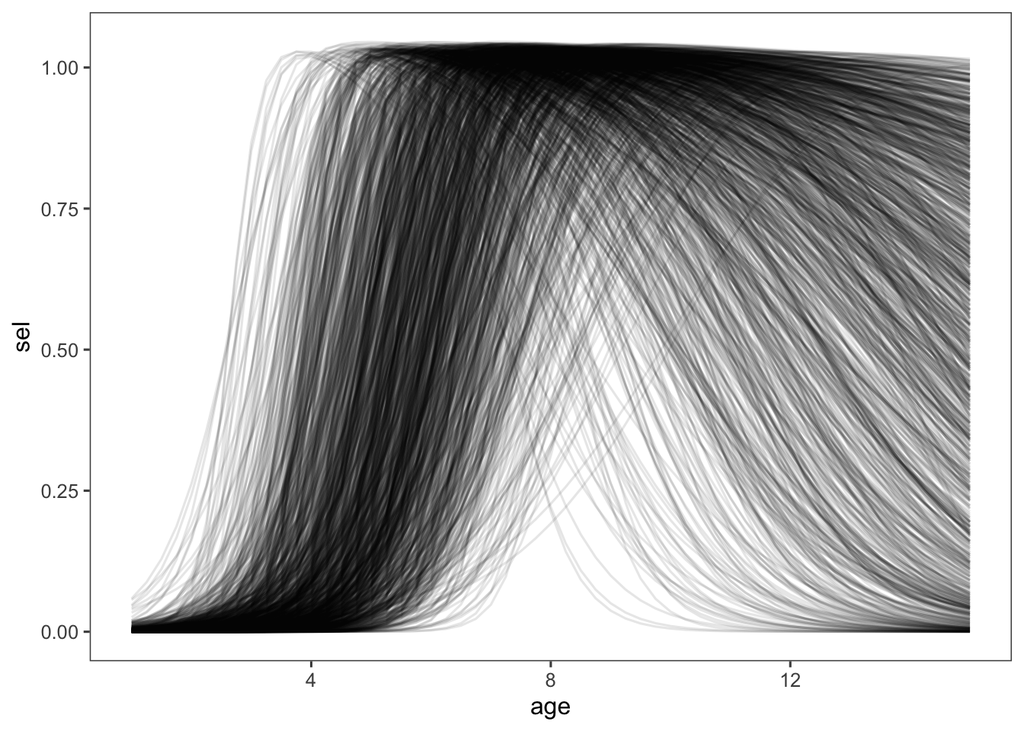

Figure 7: MCMC selectivity draws for prior set 2 (p1 median 1.5, p3 median 8, p2 sd 1).

```r
df_set2 <- mcmc_selectivity_df(fit_set2, age)
plot_mcmc_selectivity(df_set2)
```

**Show R code**

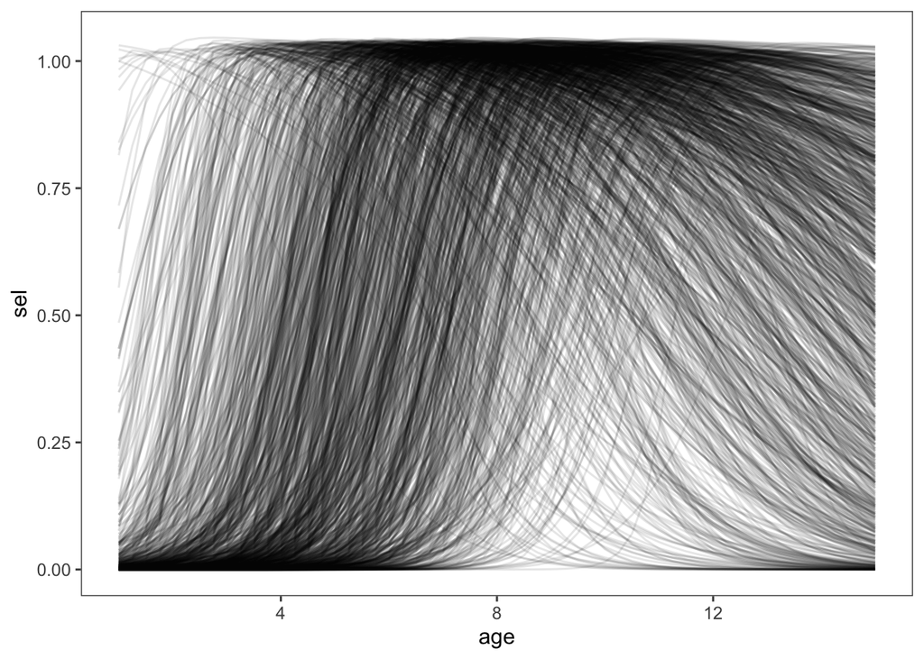

Figure 8: MCMC selectivity draws for prior set 3 (p1 median 1.5, p3 median 8, p2 sd 2).

```r
df_set3 <- mcmc_selectivity_df(fit_set3, age)
plot_mcmc_selectivity(df_set3)
```

## References

Punt, André E., Felipe Hurtado-Ferro, and Athol R. Whitten. 2013. “Model Selection for Selectivity in Fisheries Stock Assessments.” *Fisheries Research* 141: 1–12. https://doi.org/10.1016/j.fishres.2013.02.008.

Thompson, Grant G. 1994. “Confounding of Gear Selectivity and the Natural Mortality Rate in Cases Where the Former Is a Nonmonotone Function of Age.” *Canadian Journal of Fisheries and Aquatic Sciences* 51 (12): 2654–65. https://doi.org/10.1139/f94-265.